# Time Series: A First Course with Bootstrap Starter

# Lesson 4-8: Projection of Signals

- We investigate signal extraction through the device of *latent processes*.

## Latent Processes

- Suppose $\{ W_t \}$ and $\{ Z_t \}$ are independent of each other.
- Suppose $X_t = W_t + Z_t$. They are both called latent processes of $\{ X_t \}$.

## Signal and Noise

- The dynamics of $\{ X_t \}$ are a combination of those of the latent processes.
- The autocovariance functions sum up, due to independence:
  $$\gamma_X = \gamma_W + \gamma_Z.$$
- Perhaps we are interested in $\{ Z_t \}$, and $\{ W_t \}$ is viewed as irrelevant. Then $Z_t$ is *signal* and $W_t$ is *noise*.

### Example 4.8.3. Latent AR(1) with White Noise

- Suppose $\{ Z_t \}$ is an AR(1) and $\{ W_t \}$ is white noise of variance $\sigma^2$.
- We suppose the autoregressive parameter is $\phi$ and the error variance is $q \sigma^2$, for some $q > 0$.
- Recall that $\gamma_Z (h) = \phi^{|h|} {(1- \phi^2)}^{-1} q \sigma^2$.
- Then
  $$\begin{align*}
  \gamma_X (0) & = {(1- \phi^2)}^{-1} q \sigma^2 + \sigma^2 \\
  \gamma_X (h) & = \phi^{|h|} {(1- \phi^2)}^{-1} q \sigma^2 \quad h
  \neq 0.
  \end{align*}$$
- We can view the impact of $q$ on the autocovariance, with $\phi = .7$ and $\sigma = 1$
- First we examine the case with $q=1$. Second, we decrease to $q = .1$, which makes the noise relatively stronger, thus dampening the serial correlation.

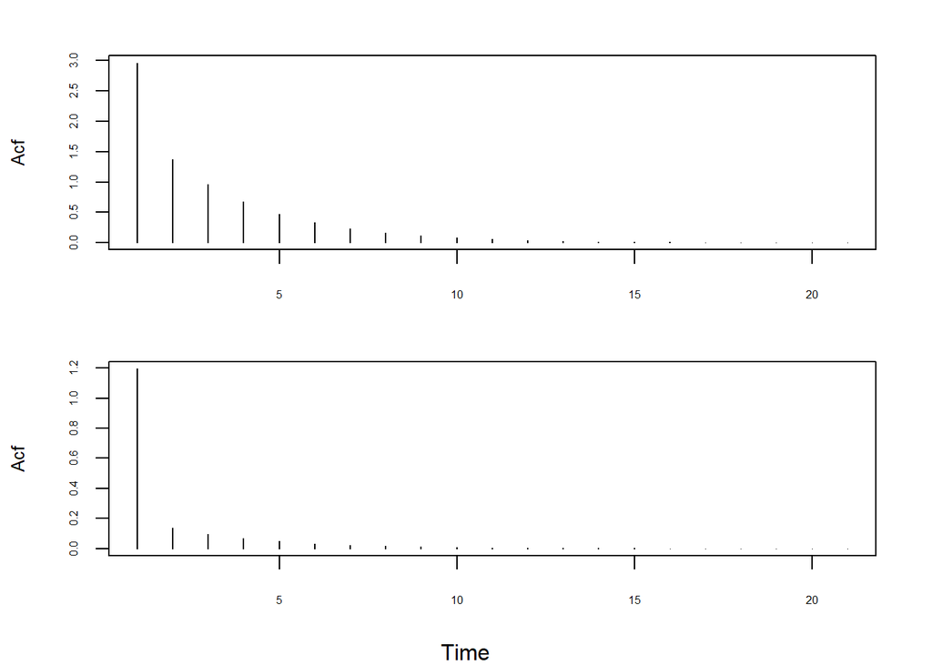

```r
snr <- 1
phi <- .7
gamma <- snr*phi^{seq(0,20)}/(1-phi^2)
gamma[1] <- gamma[1] + 1
par(oma=c(2,0,0,0),mar=c(2,4,2,2)+0.1,mfrow=c(2,1),cex.lab=.8)
plot(ts(gamma),xlab="",ylab="Acf",yaxt="n",xaxt="n",type="h")
axis(1,cex.axis=.5)
axis(2,cex.axis=.5)

snr <- .1
phi <- .7
gamma <- snr*phi^{seq(0,20)}/(1-phi^2)
gamma[1] <- gamma[1] + 1
plot(ts(gamma),xlab="",ylab="Acf",yaxt="n",xaxt="n",type="h")
axis(1,cex.axis=.5)
axis(2,cex.axis=.5)
mtext(text="Time",side=1,line=1,outer=TRUE)
```

- We also examine a sample path, first with $q=1$ and second with $q = .1$.
- We see that the second simulation has less structure, and more resembles white noise.

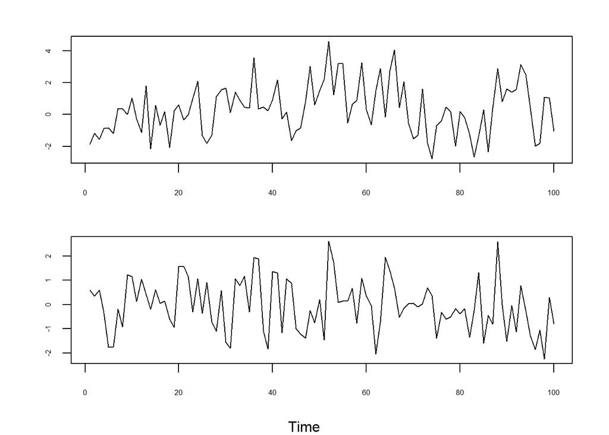

```r
snr <- 1
w <- rnorm(100)
e <- rnorm(100,sd=sqrt(snr))
z <- rep(0,100)
phi <- .7
z0 <- rnorm(1,sd=sqrt(snr))/sqrt(1-phi^2)
z[1] <- phi*z0 + e[1]
for(t in 2:100) { z[t] <- phi*z[t-1] + e[t] }
x <- z + w
par(oma=c(2,0,0,0),mar=c(2,4,2,2)+0.1,mfrow=c(2,1),cex.lab=.8)
plot(ts(x),xlab="",ylab="",yaxt="n",xaxt="n")
axis(1,cex.axis=.5)
axis(2,cex.axis=.5)

snr <- .1
w <- rnorm(100)
e <- rnorm(100,sd=sqrt(snr))
z <- rep(0,100)
phi <- .7
z0 <- rnorm(1,sd=sqrt(snr))/sqrt(1-phi^2)
z[1] <- phi*z0 + e[1]
for(t in 2:100) { z[t] <- phi*z[t-1] + e[t] }
x <- z + w
plot(ts(x),xlab="",ylab="",yaxt="n",xaxt="n")
axis(1,cex.axis=.5)
axis(2,cex.axis=.5)
mtext(text="Time",side=1,line=1,outer=TRUE)
```

## Paradigm 4.8.7. Signal Extraction

- Suppose we wish to know the signal, and get rid of the noise. This topic is called *signal extraction*.
- We can approach this as a projection problem: we project $Z_t$ (for any time $t$) onto $\{ X_t \}$. So we seek $\widehat{Z}_t = P_{ \overline{\mbox{sp}} \{ X_t \}} [Z_t]$.
- This $\widehat{Z}_t$ is a linear combination of the $\{ X_t \}$ variables, and can be written as a linear filter of $\{ X_t \}$.
- The finite-sample signal extraction problem is to find $\widehat{Z}_t = P_{ \overline{\mbox{sp}} \{ X_1, \ldots, X_n \}} [Z_t]$, for any $1 \leq t \leq n$.

### Case of White Noise

- Suppose that $\{ W_t \}$ is white noise (with variance $\sigma^2$), and that the signal $\{ Z_t \}$ is stationary.
- Then the normal equations yield
  $$\widehat{W}_t = P_{ \overline{\mbox{sp}} \{ X_1, \ldots, X_n \}} [W_t] =
  \sigma^2 \underline{e}_t^{\prime} \Gamma_n^{-1} \underline{X},$$
  where $\underline{e}_t$ is the $t$th unit vector and $\Gamma_n$ is the Toeplitz covariance matrix of $\underline{X} = {[ X_1, \ldots, X_n]}^{\prime}$.
- Then we find
  $$\widehat{Z}_t = X_t - \widehat{W}_t,$$
  which follows from $\widehat{Z}_t + \widehat{W}_t = X_t$ (by the linearity of the projection).

### Example 4.8.8. Extracting AR(1) Signal from White Noise

- We apply the signal extraction formulas to Example 4.8.3.
- The signal extraction is the dotted line, and the simulation is the solid grey line. The true latent signal is red.
- The first plot has $q=1$, the second has $q= .1$. The former has a more accurate signal extraction.

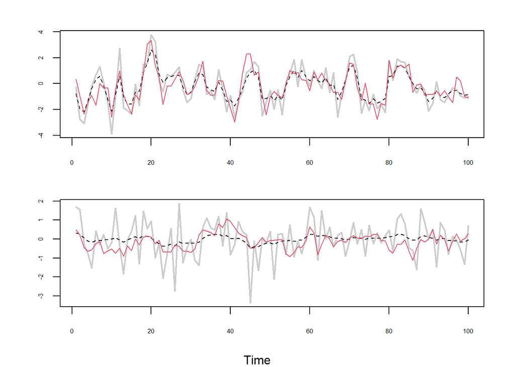

```r
snr <- 1
w <- rnorm(100)
e <- rnorm(100,sd=sqrt(snr))
z <- rep(0,100)
phi <- .7
z0 <- rnorm(1,sd=sqrt(snr))/sqrt(1-phi^2)
z[1] <- phi*z0 + e[1]
for(t in 2:100) { z[t] <- phi*z[t-1] + e[t] }
x <- z + w
gamma <- snr*phi^{seq(0,99)}/(1-phi^2)
gamma[1] <- gamma[1] + 1
zhat <- x - solve(toeplitz(gamma),x)
par(oma=c(2,0,0,0),mar=c(2,4,2,2)+0.1,mfrow=c(2,1),cex.lab=.8)
plot(ts(x),xlab="",ylab="",col=gray(.8),lwd=2,yaxt="n",xaxt="n")
axis(1,cex.axis=.5)
axis(2,cex.axis=.5)
lines(ts(zhat),lty=2)
lines(ts(z),col=2)

snr <- .1
w <- rnorm(100)
e <- rnorm(100,sd=sqrt(snr))
z <- rep(0,100)
phi <- .7
z0 <- rnorm(1,sd=sqrt(snr))/sqrt(1-phi^2)
z[1] <- phi*z0 + e[1]
for(t in 2:100) { z[t] <- phi*z[t-1] + e[t] }
x <- z + w
gamma <- snr*phi^{seq(0,99)}/(1-phi^2)
gamma[1] <- gamma[1] + 1
zhat <- x - solve(toeplitz(gamma),x)
plot(ts(x),xlab="",ylab="",col=gray(.8),lwd=2,yaxt="n",xaxt="n")
axis(1,cex.axis=.5)
axis(2,cex.axis=.5)
lines(ts(zhat),lty=2)
lines(ts(z),col=2)
mtext(text="Time",side=1,line=1,outer=TRUE)
```

## Paradigm 4.8.9. Time Series Interpolation.

- Suppose that we have a single time series with an NA at time $t$.
- We can approach as a projection problem: we project $X_t$ onto $\{ X_s, s \neq t \}$. So we seek $\widehat{X}_t = P_{ \overline{\mbox{sp}} \{ X_s, s \neq t \}} [X_t]$.
- This $\widehat{X}_t$ is a linear combination of the $\{ X_s, s\neq t \}$ variables, and can be written as a linear filter of them.
- The finite-sample interpolation problem is to find $\widehat{X}_t = P_{ \overline{\mbox{sp}} \{ X_1, \ldots, X_{t-1}, X_{t+1}, \ldots, X_n \}} [X_t]$.
- Then the normal equations yield
  $$\widehat{X}_t = \underline{\upsilon}^{\prime} \Gamma_{n-1}^{-1} { [X_1,
  \ldots, X_{t-1}, X_{t+1}, \ldots, X_n ]}^{\prime},$$
  where $\underline{\upsilon} = {[\gamma (t-1), \ldots, \gamma(1), \gamma(-1), \ldots, \gamma (t-n)]}^{\prime}$ and $\Gamma_{n-1}$ is the Toeplitz covariance matrix of ${ [X_1, \ldots, X_{t-1}, X_{t+1}, \ldots, X_n ]}^{\prime}$.
- This is verified by checking the normal equations.

### Example: Interpolation for an AR(1) Process.

- Consider an AR(1) process. We claim that
  $$\widehat{X}_t = \frac{\phi}{1 + \phi^2} ( X_{t+1} + X_{t-1}),$$
  which is verified through checking the normal equations.
- We apply the missing value interpolation to an AR(1) simulation.
- The red dot is the imputation, and the green square is the true value (which we treat as missing).

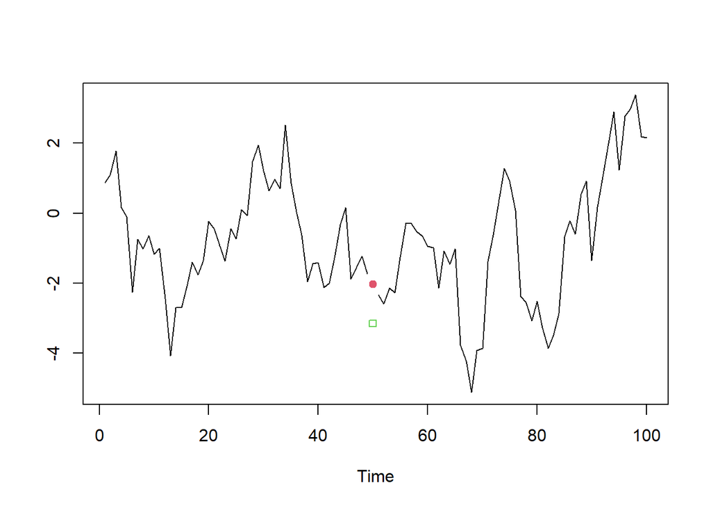

```r
phi <- .9
e <- rnorm(100,sd=1)
x <- rep(0,100)
x0 <- rnorm(1,sd=1)/sqrt(1-phi^2)
x[1] <- phi*x0 + e[1]
for(t in 2:100) { x[t] <- phi*x[t-1] + e[t] }
x.val <- x[50]
x[50] <- NA
xhat <- (phi/(1+phi^2))*(x[49]+x[51])
plot(ts(x),ylab="")
points(ts(c(rep(NA,49),xhat,rep(NA,50))),col=2,pch=19)
points(ts(c(rep(NA,49),x.val,rep(NA,50))),col=3,pch=22)
```